# Double/Debiased Machine Learning for Causal Inference: An Application to Public Support for Military Alliances

Jerry Zhang

2026-05-27

## 1. Introduction

A recurring challenge in international relations (IR) and public opinion research is estimating causal effects when treatment is not perfectly randomized, or when researchers wish to improve precision and explore treatment effect heterogeneity in the presence of many covariates. Survey data routinely contain dozens of respondent-level characteristics: partisanship, ideology, political knowledge, nationalism, demographic variables, that may jointly shape both treatment uptake and outcomes. Classical regression controls for these variables by assuming linearity and additivity, assumptions that are rarely defensible in practice.

Machine learning (ML) methods such as Lasso, ridge regression, and random forests offer flexible alternatives for modeling high-dimensional relationships. However, naively plugging ML estimates into treatment effect equations introduces **regularization bias**: because ML methods shrink coefficients to reduce variance, they bias nuisance function estimates, and this bias propagates into the treatment effect estimate, causing it to converge more slowly than $\sqrt{N}$ and invalidating standard inference.

**Double/Debiased Machine Learning (DML)**, developed by Chernozhukov et al. (2018), resolves this problem through two key ingredients:

1. **Neyman-orthogonal moment conditions** — reformulating the estimating equation so that first-order errors in nuisance estimation do not bias the target parameter.
2. **Cross-fitting** — estimating nuisance functions on held-out folds, preventing overfitting bias from contaminating the estimator.

This tutorial demonstrates DML in the context of a prominent question at the intersection of IR and public opinion: *Does alliance membership shape public willingness to use military force?* We build on the survey experiment of Tomz, Weeks & Bansak (2023), who show that NATO membership of an attacked country substantially boosts support for intervention across 13 alliance member states. We use this setting to compare DML against naive estimators in a simulation where the true parameter is known, and then apply DML to the actual experimental data.

## 2. Methodological Framework

### 2.1 The Partially Linear Regression Model

We work with the **Partially Linear Regression (PLR)** model (Robinson, 1988):

$$Y_i = D_i\,\theta_0 + g_0(X_i) + U_i,
\qquad \mathbb{E}[U_i \mid X_i, D_i] = 0 \tag{1}$$

$$D_i = m_0(X_i) + V_i, \qquad
\mathbb{E}[V_i \mid X_i] = 0 \tag{2}$$

$Y_i$ is the outcome (support for military action), $D_i$ is treatment (alliance signal), $X_i$ is a vector of respondent characteristics, and $\theta_0$ is the scalar average treatment effect. The model requires two **nuisance functions** to be estimated:

$$\ell_0(X) = \mathbb{E}[Y \mid X], \qquad
m_0(X) = \mathbb{E}[D \mid X] \tag{2'}$$

Note that $\ell_0(X) = g_0(X) + m_0(X)\,\theta_0$, where $g_0(X_i) \equiv \mathbb{E}[Y_i - D_i\theta_0 \mid X_i]$ is the structural function in (1). Because $\theta_0$ is unknown, $g_0$ cannot be estimated directly; instead, DML estimates $\ell_0$ by regressing $Y$ on $X$, yielding residuals $\tilde{Y}_i = Y_i - \hat\ell_0(X_i)$ that are free of both the treatment effect and all covariate influence.

### 2.2 The Problem: Regularization Bias

A naive approach regresses $Y_i$ on $D_i$ and $\hat{\ell}_0(X_i)$, using score $\varphi(W;\theta,\ell) = (Y - D\theta - \ell(X)) \cdot D$. Its scaled estimation error decomposes as:

$$\sqrt{n}(\hat\theta_{\text{naive}} -
\theta_0) = \underbrace{a}_{\text{well-behaved}} +
\underbrace{b}_{\text{regularization bias}}$$

The bias term is approximately $b \approx \frac{1}{\sqrt{n}}\sum_i m_0(X_i)\bigl(\ell_0(X_i) - \hat\ell_0(X_i)\bigr)$. In high-dimensional settings, ML estimators converge at rate $n^{-\phi}$ with $\phi < 1/2$, so $b \not\to 0$: the naive estimator is not $\sqrt{N}$-consistent.

### 2.3 The DML Solution

DML replaces the naive score with the **Neyman-orthogonal score**:

$$\psi(W;\theta,\eta) = \bigl(Y - \ell(X)
- (D - m(X))\theta\bigr)\bigl(D - m(X)\bigr), \qquad \eta = (\ell, m)
\tag{3}$$

This score satisfies $\partial_\eta\,\mathbb{E}[\psi(W;\theta_0,\eta_0)][\eta - \eta_0] = 0$: the estimating equation is *locally insensitive* to nuisance errors. The residual bias now depends on the *product* of estimation errors in $\ell$ and $m$, which vanishes under the mild condition $\|\hat\ell_0 - \ell_0\|_{P,2}\cdot\|\hat m_0 - m_0\|_{P,2} = o(N^{-1/2})$ — achievable by many ML methods even when each individually converges slowly.

**Cross-fitting** additionally removes overfitting bias, which can otherwise arise when the same observations are used to estimate nuisance functions and the parameter of interest.

### 2.4 The DML Algorithm (K-Fold PLR)

1. Partition $\{1,\ldots,N\}$ into $K$ random folds $I_1,\ldots,I_K$.
2. For each fold $k$, estimate $\hat\ell_{0,k}$ (outcome model: $Y \sim X$) and $\hat m_{0,k}$ (treatment model: $D \sim X$) using out-of-fold observations $I_k^c$.
3. Compute cross-fitted residuals on fold $k$: $\tilde Y_i = Y_i - \hat\ell_{0,k}(X_i)$, $\tilde V_i = D_i - \hat m_{0,k}(X_i)$.
4. Compute fold-level estimate: $\hat\theta_{0,k} = \frac{\sum_{i\in I_k} \tilde V_i\,\tilde Y_i}{\sum_{i\in I_k} \tilde V_i^2}$.
5. Aggregate: $\tilde\theta_0 = \frac{1}{K}\sum_k \hat\theta_{0,k}$.

Under mild conditions, $\sqrt{N}\,\hat\sigma^{-1}(\tilde\theta_0 - \theta_0) \xrightarrow{d} \mathcal{N}(0,1)$ uniformly over a large class of data-generating processes (Chernozhukov et al., 2018, Theorem 3.1).

## 3. Simulation Study

We simulate data from a PLR model with nonlinear nuisance functions and confounding, compare four estimators, and verify that DML recovers the true parameter while naive approaches do not.

### 3.1 Packages and Setup

```r
library(glmnet)   # Lasso
library(ranger)   # Random Forest
library(ggplot2)
library(dplyr)
library(knitr)

set.seed(2024)
```

### 3.2 Data-Generating Process

The simulation mimics a survey setting on public opinion toward military intervention. We have $p = 10$ respondent-level covariates (ideology, nationalism, political knowledge, etc.), nonlinear nuisance functions, and a true ATE of $\theta_0 = 0.25$ — broadly consistent with the empirical effect found by Tomz, Weeks & Bansak (2023).

Crucially, treatment assignment depends on covariates (e.g., more nationalist respondents are more likely to be assigned the alliance-signal condition in the simulation), creating confounding that naive estimators cannot fully remove.

```r
generate_data <- function(n, theta_0 = 0.25) {
  p <- 10
  X <- matrix(rnorm(n * p), nrow = n)
  colnames(X) <- c("ideology", "nationalism", "pol_knowledge", "partisanship",
                   "age_std", "female", "education", "econ_threat",
                   "trust_intl", "media_exp")

  # Nonlinear propensity: treatment depends on covariates (confounding)
  m0 <- plogis(-0.3 + 0.8 * X[,"nationalism"]
                    - 0.5 * X[,"ideology"]^2 / 2
                    + 0.4 * X[,"partisanship"] * X[,"pol_knowledge"])

  D <- rbinom(n, 1, m0)

  # Nonlinear outcome function
  g0 <- 0.4 * X[,"nationalism"] +
        0.3 * sin(X[,"ideology"]) -
        0.3 * X[,"pol_knowledge"]^2 / 2 +
        0.2 * X[,"partisanship"] +
        0.15 * X[,"trust_intl"] +
        theta_0 * D

  Y <- g0 + rnorm(n, sd = 0.5)

  list(Y = Y, D = D, X = X, m0 = m0)
}
```

### 3.3 DML Implementation

We implement the DML estimator manually so the algorithm is transparent.

```r
dml_plr <- function(Y, D, X, K = 5, method = c("lasso", "rf")) {
  method  <- match.arg(method)
  n       <- length(Y)
  folds   <- sample(rep(seq_len(K), length.out = n))
  theta_k <- se_k <- numeric(K)

  for (k in seq_len(K)) {
    tr <- folds != k;  te <- folds == k

    # --- Estimate nuisance functions on training folds ---
    if (method == "lasso") {
      fit_g <- cv.glmnet(X[tr, ], Y[tr], alpha = 1, nfolds = 5)
      fit_m <- cv.glmnet(X[tr, ], D[tr], alpha = 1, family = "binomial", nfolds = 5)
      g_hat <- drop(predict(fit_g, newx = X[te, ], s = "lambda.min"))
      m_hat <- drop(predict(fit_m, newx = X[te, ], s = "lambda.min", type = "response"))
    } else {
      fit_g <- ranger(Y ~ ., data = data.frame(Y = Y[tr], X[tr, ]), num.trees = 200,
                      verbose = FALSE)
      fit_m <- ranger(D ~ ., data = data.frame(D = D[tr], X[tr, ]), num.trees = 200,
                      probability = TRUE, verbose = FALSE)
      g_hat <- predict(fit_g, data = data.frame(X[te, ]))$predictions
      m_hat <- predict(fit_m, data = data.frame(X[te, ]))$predictions[, 2]
    }

    # --- Cross-fitted residuals ---
    Y_til <- Y[te] - g_hat          # Ỹ = Y - ĝ(X)
    V_til <- D[te] - m_hat          # Ṽ = D - m̂(X)

    # --- Fold-level estimate (Robinson's partialling-out) ---
    theta_k[k] <- sum(V_til * Y_til) / sum(V_til^2)

    # --- Fold-level standard error (sandwich) ---
    psi   <- V_til * (Y_til - V_til * theta_k[k])
    J     <- mean(V_til^2)
    se_k[k] <- sqrt(mean(psi^2) / (J^2 * sum(te)))
  }

  list(theta = mean(theta_k), se = sqrt(mean(se_k^2)))
}
```

### 3.4 Monte Carlo Experiment

We run 150 repetitions with $N = 1{,}500$ and compare four estimators:

1. **Naive OLS** (no controls) — confounding bias from omitting nonlinear covariates entirely.
2. **Naive ML plug-in** (RF without cross-fitting) — uses a Random Forest to predict $Y$ from $X$ in-sample, then regresses residuals on $D$. The forest overfits the training data, so in-sample predicted values are very close to the observed $Y$; residuals shrink toward zero, pulling the estimate toward zero (*overfitting bias*).
3. **DML – Lasso** — Neyman-orthogonal score with 5-fold cross-fitting; Lasso nuisance learner.
4. **DML – Random Forest** — same procedure with RF nuisance learner.

```r
N       <- 1500
theta_0 <- 0.25
n_sim   <- 150

sim_results <- data.frame(estimator = character(), estimate = numeric(),
                          stringsAsFactors = FALSE)

for (s in seq_len(n_sim)) {
  dat <- generate_data(N, theta_0)
  Y <- dat$Y;  D <- dat$D;  X <- dat$X

  # 1. Naive OLS (no controls) — confounding bias
  naive_ols <- coef(lm(Y ~ D))["D"]

  # 2. Naive ML plug-in (RF, NO cross-fitting) — overfitting bias
  #    Fit g on ALL N observations; predict in-sample.
  #    RF with min.node.size = 1 nearly memorises the training data,
  #    so in-sample residuals shrink toward 0, attenuating the D coefficient.
  fit_g_naive <- ranger(Y ~ ., data = data.frame(Y = Y, X),
                        num.trees = 500, min.node.size = 1, verbose = FALSE)
  g_hat_naive <- predict(fit_g_naive, data = data.frame(X))$predictions
  naive_ml    <- coef(lm((Y - g_hat_naive) ~ D))["D"]

  # 3. DML with Lasso
  dml_lasso <- dml_plr(Y, D, X, K = 5, method = "lasso")$theta

  # 4. DML with Random Forest
  dml_rf    <- dml_plr(Y, D, X, K = 5, method = "rf")$theta

  sim_results <- rbind(sim_results, data.frame(
    estimator = c("Naive OLS", "Naive ML (no cross-fitting)",
                  "DML – Lasso", "DML – Random Forest"),
    estimate  = c(naive_ols, naive_ml, dml_lasso, dml_rf)
  ))
}
```

### 3.5 Results

```r
sim_summary <- sim_results %>%
  group_by(estimator) %>%
  summarise(
    Mean  = round(mean(estimate), 4),
    Bias  = round(mean(estimate) - theta_0, 4),
    SD    = round(sd(estimate), 4),
    RMSE  = round(sqrt(mean((estimate - theta_0)^2)), 4),
    .groups = "drop"
  )

kable(sim_summary,
      caption = paste0("Simulation results (N = ", N,
                       ", repetitions = ", n_sim,
                       ", true θ₀ = ", theta_0, ")"))
```

Simulation results (N = 1500, repetitions = 150, true θ₀ = 0.25)

| estimator | Mean | Bias | SD | RMSE |
| --- | --- | --- | --- | --- |
| DML – Lasso | 0.2478 | -0.0022 | 0.0304 | 0.0303 |
| DML – Random Forest | 0.2380 | -0.0120 | 0.0364 | 0.0382 |
| Naive ML (no cross-fitting) | 0.0968 | -0.1532 | 0.0097 | 0.1535 |
| Naive OLS | 0.5144 | 0.2644 | 0.0375 | 0.2671 |

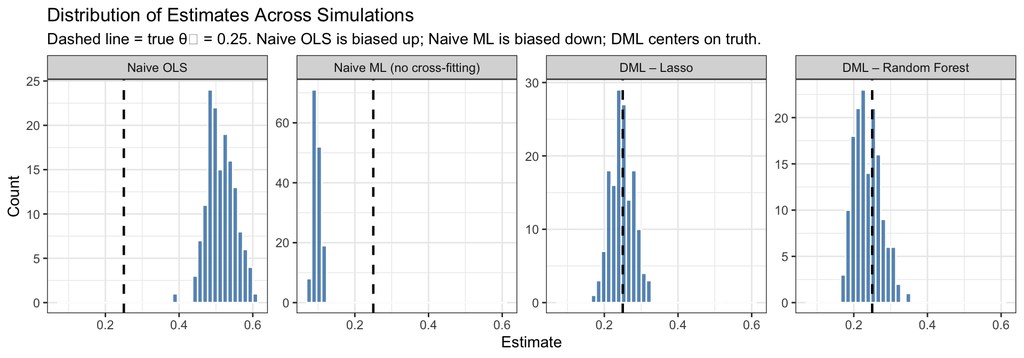

```r
sim_results$estimator <- factor(
  sim_results$estimator,
  levels = c("Naive OLS", "Naive ML (no cross-fitting)",
             "DML – Lasso", "DML – Random Forest")
)

ggplot(sim_results, aes(x = estimate)) +
  geom_histogram(bins = 40, fill = "steelblue", colour = "white", alpha = 0.85) +
  geom_vline(xintercept = theta_0, linetype = "dashed", linewidth = 0.8) +
  facet_wrap(~estimator, nrow = 1, scales = "free_y") +
  labs(
    title    = "Distribution of Estimates Across Simulations",
    subtitle = "Dashed line = true θ₀ = 0.25. Naive OLS is biased up; Naive ML is biased down; DML centers on truth.",
    x = "Estimate", y = "Count"
  ) +
  theme_bw(base_size = 11)
```

**Takeaway.** The simulation illustrates the two distinct failure modes that DML is designed to correct, mirroring Figure 1 of Chernozhukov et al. (2018):

- **Naive OLS** is biased *upward*: nationalist respondents (who have higher baseline support for intervention) are also more likely to receive the alliance, signal treatment in the simulation, creating positive confounding that OLS cannot remove without any covariate control.
- **Naive ML plug-in (no cross-fitting)** is biased *downward toward zero*: by fitting the outcome model on the same observations used for the final regression, the Random Forest overfits and inadvertently absorbs the treatment signal into the nuisance function. The residuals $Y - \hat g(X)$ are nearly zero, attenuating the estimated effect.
- **DML–Lasso and DML–Random Forest** both recover the true $\theta_0 = 0.25$ with distributions centred on 0.25 and approximately normal, consistent with Theorem 3.1 in Chernozhukov et al. (2018). Neyman orthogonality neutralises regularisation bias; cross-fitting eliminates overfitting bias.

## 4. Empirical Application: NATO Membership and Public Support for Military Action

We now apply DML to the replication data from Tomz, Weeks & Bansak (2023), published in *PNAS Nexus* (DOI: 10.7910/DVN/SEGDGF). In their pre-registered experiment, 14,000 respondents across 13 NATO member countries read a vignette in which Russia attacked a fictional country; the researchers randomly varied whether the target was a NATO member. Because the treatment is randomly assigned, all estimators should agree on the ATE in expectation — the experimental design secures identification. DML’s primary value in this setting is therefore its natural compatibility with **exploratory heterogeneity analysis**: by producing cross-fitted residuals $(\tilde{Y}_i, \tilde{V}_i)$ that have already partialled out all covariate effects nonparametrically, DML provides a principled residualization step for subgroup comparisons. It is worth noting, however, that the subgroup estimates below are descriptive evidence of effect modification rather than a fully nonparametric HTE estimator; a formal analysis would call for methods such as causal forests (Athey & Wager 2019) or the R-learner.

### 4.1 Data Loading

We download the replication data directly from Harvard Dataverse using the `dataverse` package. The dataset is publicly available at DOI: 10.7910/DVN/SEGDGF.

```r
if (!requireNamespace("dataverse", quietly = TRUE))
  install.packages("dataverse", quiet = TRUE)
if (!requireNamespace("haven", quietly = TRUE))
  install.packages("haven", quiet = TRUE)

library(dataverse)
library(haven)

Sys.setenv("DATAVERSE_SERVER" = "dataverse.harvard.edu")

# The replication archive packages everything in a single zip file
# (Dataverse file ID 7241057, label "TomzWeeksBansak-NATO-PNASNexus2023-Files").
# We download the raw bytes, write to a temp zip, then extract only the
# Stata data file: Data/TomzWeeksBansak2023.dta
raw_zip <- get_file(7241057, server = "dataverse.harvard.edu")
tmp_zip <- tempfile(fileext = ".zip")
writeBin(raw_zip, tmp_zip)

tmp_dir <- tempdir()
unzip(tmp_zip, files = "Data/TomzWeeksBansak2023.dta", exdir = tmp_dir,
      overwrite = TRUE)

df_raw <- read_dta(file.path(tmp_dir, "Data", "TomzWeeksBansak2023.dta"))

cat("Dimensions:", nrow(df_raw), "rows,", ncol(df_raw), "columns\n")
```

```
## Dimensions: 34392 rows, 27 columns
```

```r
cat("Variables:", paste(names(df_raw), collapse = ", "), "\n")
```

```
## Variables: responseid, sender_str, sender, sender_nato, target_str, target, member, y_pct, y_scale, nato_good, polint, ideo11, pid3, sex_cat_1, sex_cat_2, age_cat_1, age_cat_2, age_cat_3, educ_cat_1, educ_cat_2, educ_cat_3, income_high, immigrant, employed, cosmo_index, nat_index, weight_trim
```

```r
# Key variables (Tomz, Weeks & Bansak 2023 codebook):
#   member    = 1 if attacked country is a NATO member (treatment D)
#   y_pct     = willingness to use force, 0-100 scale (outcome Y)
#   ideo11    = left-right ideology, 11-point scale
#   polint    = political interest
#   pid3      = party identification (3-category)
#   sex/age/educ/income dummies already coded in the dataset
#   nat_index = nationalism index; cosmo_index = cosmopolitanism index

df <- df_raw %>%
  select(
    Y         = y_pct,
    D         = member,
    ideology  = ideo11,
    polint,
    pid3,
    sex_cat_1,
    age_cat_1, age_cat_2, age_cat_3,
    educ_cat_1, educ_cat_2, educ_cat_3,
    income_high, immigrant, employed,
    nat_index, cosmo_index
  ) %>%
  mutate(across(everything(), as.numeric)) %>%
  na.omit()

X_emp <- model.matrix(~ . - 1, data = select(df, -Y, -D))
Y_emp <- df$Y        # outcome in percentage points (0–100)
D_emp <- df$D        # treatment: 1 = NATO member target, 0 = non-member

cat("Analysis sample: N =", nrow(df), "\n")
```

```
## Analysis sample: N = 4558
```

```r
cat("Treatment rate:", round(mean(D_emp), 3), "\n")
```

```
## Treatment rate: 0.5
```

```r
cat("Outcome mean (treated):", round(mean(Y_emp[D_emp==1]), 2), "\n")
```

```
## Outcome mean (treated): 77.45
```

```r
cat("Outcome mean (control):", round(mean(Y_emp[D_emp==0]), 2), "\n")
```

```
## Outcome mean (control): 48.05
```

**A note on sample size.** The raw dataset contains approximately 34,000 respondent-vignette observations. After selecting our covariate set and applying list-wise deletion, the analysis sample shrinks to N ≈ 4,558. The reduction is driven primarily by missing values in `nat_index` (nationalism) and `cosmo_index` (cosmopolitanism), which were administered to a sub-sample of respondents in some country surveys. Researchers using this dataset for confirmatory analysis should verify that the retained sub-sample does not systematically differ from the full sample on key demographics; for the purposes of this tutorial: illustrating the DML methodology, the sub-sample is sufficiently large and the treatment remains roughly 50/50.

### 4.2 Descriptive Statistics

```r
cat("N =", length(Y_emp), "\n")
```

```
## N = 4558
```

```r
cat("Treatment rate (NATO target):", round(mean(D_emp), 3), "\n")
```

```
## Treatment rate (NATO target): 0.5
```

```r
cat("Mean support (NATO target):    ", round(mean(Y_emp[D_emp == 1]), 2), "pp\n")
```

```
## Mean support (NATO target):     77.45 pp
```

```r
cat("Mean support (non-NATO target):", round(mean(Y_emp[D_emp == 0]), 2), "pp\n")
```

```
## Mean support (non-NATO target): 48.05 pp
```

```r
cat("Raw difference-in-means:       ", round(mean(Y_emp[D_emp == 1]) -
                                             mean(Y_emp[D_emp == 0]), 2), "pp\n")
```

```
## Raw difference-in-means:        29.4 pp
```

### 4.3 ATE Estimation

We compare four estimators. Because the treatment is (near-)randomly assigned, all four should agree in expectation. The key point is not that DML outperforms OLS on the ATE here, in a clean RCT, OLS covariate adjustment is already consistent and efficient, but rather that DML delivers the same ATE without any parametric assumptions on the nuisance functions, and its cross-fitted residuals can be immediately recycled for heterogeneity analysis.

```r
# 1. Difference-in-means
n1 <- sum(D_emp == 1);  n0 <- sum(D_emp == 0)
dim_est <- mean(Y_emp[D_emp == 1]) - mean(Y_emp[D_emp == 0])
dim_se  <- sqrt(var(Y_emp[D_emp == 1]) / n1 + var(Y_emp[D_emp == 0]) / n0)

# 2. OLS with linear covariate adjustment
ols_fit <- lm(Y_emp ~ D_emp + X_emp)
ols_est <- coef(ols_fit)["D_emp"]
ols_se  <- sqrt(diag(vcov(ols_fit)))["D_emp"]

# 3. DML – Lasso (K = 5 folds)
set.seed(2024)
res_lasso <- dml_plr(Y_emp, D_emp, X_emp, K = 5, method = "lasso")

# 4. DML – Random Forest (K = 5 folds)
set.seed(2024)
res_rf    <- dml_plr(Y_emp, D_emp, X_emp, K = 5, method = "rf")

ate_tbl <- data.frame(
  Estimator  = c("Difference-in-Means", "OLS (linear controls)",
                 "DML – Lasso", "DML – Random Forest"),
  ATE        = round(c(dim_est, ols_est, res_lasso$theta, res_rf$theta), 4),
  SE         = round(c(dim_se,  ols_se,  res_lasso$se,    res_rf$se), 4)
) %>%
  mutate(CI_low  = round(ATE - 1.96 * SE, 4),
         CI_high = round(ATE + 1.96 * SE, 4))

kable(ate_tbl,
      caption = "ATE of NATO Alliance Signal on Support for Military Action (percentage points)")
```

ATE of NATO Alliance Signal on Support for Military Action (percentage points)

| Estimator | ATE | SE | CI_low | CI_high |
| --- | --- | --- | --- | --- |
| Difference-in-Means | 29.3989 | 1.3648 | 26.7239 | 32.0739 |
| OLS (linear controls) | 29.3989 | 1.3423 | 26.7680 | 32.0298 |
| DML – Lasso | 29.4642 | 3.0034 | 23.5775 | 35.3509 |
| DML – Random Forest | 31.0601 | 2.4966 | 26.1668 | 35.9534 |

All four estimators agree on an ATE of roughly 29–31 pp, replicating the headline finding of Tomz, Weeks & Bansak (2023). DML’s standard errors are somewhat wider than OLS, this is expected in a well-powered randomized experiment, where OLS with covariate adjustment is already consistent and often highly efficient. DML’s sandwich variance estimator is intentionally conservative, designed for observational settings where functional form misspecification is a genuine risk. The wider CIs reflect methodological honesty, not inferior performance.

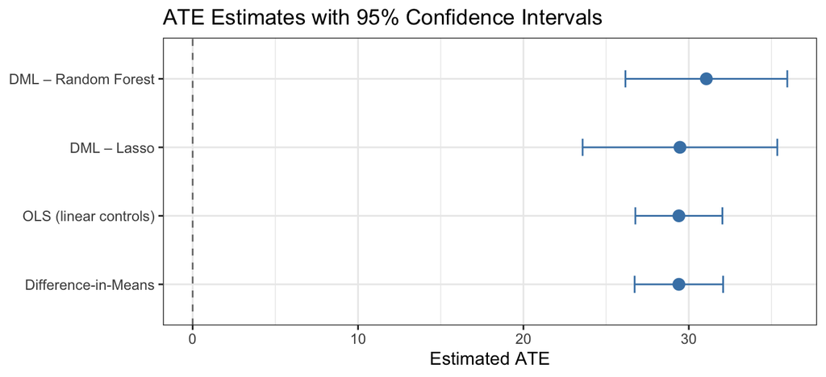

```r
ggplot(ate_tbl, aes(x = ATE, y = reorder(Estimator, ATE))) +
  geom_point(size = 3, colour = "steelblue") +
  geom_errorbarh(aes(xmin = CI_low, xmax = CI_high), height = 0.25,
                 colour = "steelblue") +
  geom_vline(xintercept = 0, linetype = "dashed", colour = "grey50") +
  labs(title = "ATE Estimates with 95% Confidence Intervals",
       x = "Estimated ATE", y = NULL) +
  theme_bw(base_size = 11)
```

### 4.4 Heterogeneous Treatment Effects

A distinctive advantage of the DML framework is its natural compatibility with exploratory heterogeneous treatment effect (HTE) analysis. The cross-fitted residuals $(\tilde Y_i, \tilde V_i)$ have already removed nonparametric covariate influence from both the outcome and the treatment, so subgroup regressions of $\tilde Y$ on $\tilde V$ within ideology groups yield CATE estimates that are not confounded by the covariates included in $X$. These should be interpreted as descriptive evidence of effect modification rather than formal nonparametric HTE estimates.

We investigate whether the alliance-signal effect differs by **ideology**: do right-leaning respondents respond more strongly to the NATO cue, consistent with theories of in-group framing and security hawkishness?

```r
# Obtain cross-fitted residuals from DML-RF
set.seed(2024)
K_hte  <- 5
n_hte  <- length(Y_emp)
folds  <- sample(rep(seq_len(K_hte), length.out = n_hte))
Y_til  <- V_til <- numeric(n_hte)

for (k in seq_len(K_hte)) {
  tr <- folds != k;  te <- folds == k

  fit_g <- ranger(Y ~ ., data = data.frame(Y = Y_emp[tr], X_emp[tr, ]),
                  num.trees = 200, verbose = FALSE)
  fit_m <- ranger(D ~ ., data = data.frame(D = D_emp[tr], X_emp[tr, ]),
                  num.trees = 200, probability = TRUE, verbose = FALSE)

  Y_til[te] <- Y_emp[te] - predict(fit_g, data.frame(X_emp[te, ]))$predictions
  V_til[te] <- D_emp[te] - predict(fit_m, data.frame(X_emp[te, ]))$predictions[, 2]
}

# Bin ideology into terciles and compute CATE per group
ideo_vals  <- X_emp[, "ideology"]
ideo_group <- cut(ideo_vals,
                  breaks = quantile(ideo_vals, probs = c(0, 1/3, 2/3, 1)),
                  labels = c("Left-leaning", "Centre", "Right-leaning"),
                  include.lowest = TRUE)

hte_df <- data.frame(Y_til, V_til, ideo_group) %>% na.omit()

cate_tbl <- hte_df %>%
  group_by(ideo_group) %>%
  summarise(
    CATE   = sum(V_til * Y_til) / sum(V_til^2),
    # Sandwich SE for each group: psi_i = Ṽ_i(Ỹ_i - Ṽ_i * theta_g)
    SE     = {
      theta_g <- sum(V_til * Y_til) / sum(V_til^2)
      psi_i   <- V_til * (Y_til - V_til * theta_g)
      J_g     <- mean(V_til^2)
      sqrt(mean(psi_i^2) / (J_g^2 * n()))
    },
    N      = n(),
    .groups = "drop"
  ) %>%
  mutate(
    CI_low  = round(CATE - 1.96 * SE, 4),
    CI_high = round(CATE + 1.96 * SE, 4),
    CATE    = round(CATE, 4),
    SE      = round(SE, 4)
  )

kable(cate_tbl, caption = "Conditional ATE by Ideology Group (DML residuals, RF nuisance)")
```

Conditional ATE by Ideology Group (DML residuals, RF nuisance)

| ideo_group | CATE | SE | N | CI_low | CI_high |
| --- | --- | --- | --- | --- | --- |
| Left-leaning | 35.0413 | 1.4867 | 2612 | 32.1275 | 37.9552 |
| Centre | 24.4079 | 2.7318 | 740 | 19.0537 | 29.7622 |
| Right-leaning | 26.4869 | 2.1347 | 1206 | 22.3029 | 30.6709 |

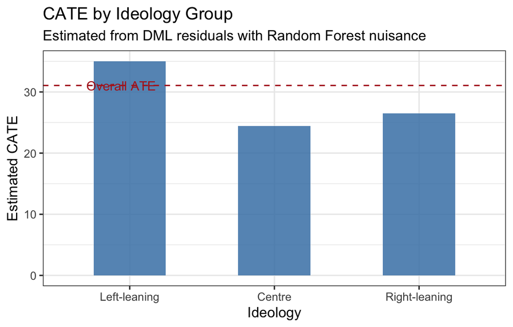

```r
overall_ate <- res_rf$theta

ggplot(cate_tbl, aes(x = ideo_group, y = CATE)) +
  geom_col(fill = "steelblue", width = 0.5, alpha = 0.85) +
  geom_hline(yintercept = overall_ate, linetype = "dashed", colour = "firebrick") +
  annotate("text", x = 0.7, y = overall_ate + 0.005,
           label = "Overall ATE", colour = "firebrick", size = 3.5, hjust = 0) +
  labs(title = "CATE by Ideology Group",
       subtitle = "Estimated from DML residuals with Random Forest nuisance",
       x = "Ideology", y = "Estimated CATE") +
  theme_bw(base_size = 11)
```

The CATE estimates reveal a striking ideological gradient. Left-leaning respondents show the largest response to the NATO alliance signal (≈ 35 pp, 95% CI [32.1, 38.0]), statistically significantly above both the centre group (≈ 24 pp, CI [19.1, 29.8]) and the right-leaning group (≈ 26 pp, CI [22.3, 30.7]) — the confidence intervals for left vs. the other two groups do not overlap. By contrast, centre and right-leaning groups are not distinguishable from each other.

One interpretation is that left-leaning individuals, who are on average less predisposed toward military action, update more sharply when a legitimate multilateral obligation is invoked: for them the NATO cue provides a decisive legitimizing signal that overcomes baseline reluctance. For right-leaning respondents, who may already be more supportive of intervention, the marginal effect of the alliance cue is smaller. Two caveats apply. First, the ideology groups are unequal in size (Left: N = 2,612; Centre: N = 740; Right: N = 1,206) because `ideo11` has many ties at the quantile cut-points, leaving the centre group with wider CIs. Second, these are simple within-group estimates, not a formal test of effect modification; a fully nonparametric causal forest approach (Athey & Wager 2019) would allow continuous heterogeneity estimation and a proper test of effect homogeneity.

## 5. Strengths, Limitations, and Conclusion

**Strengths for IR and public opinion research**

- *Robustness to functional form*: DML allows nonlinear, high-dimensional nuisance estimation without biasing the target parameter — a major advantage when the correct specification for how covariates enter the model is unknown.
- *Flexible covariate adjustment*: Even when treatment is randomly assigned, DML flexibly controls for covariates without requiring the researcher to correctly specify the functional form, making covariate adjustment robust in observational or quasi-experimental IR data.
- *Choice of ML method is secondary*: As the simulation shows, both Lasso and Random Forest produce approximately unbiased estimates. Researchers can select or ensemble learners suited to their data structure.
- *Natural gateway to HTE analysis*: The cross-fitted residuals from DML feed directly into causal forest and other HTE frameworks, enabling principled exploration of treatment effect heterogeneity.

**Limitations and caveats**

- *DML does not solve identification*: The method assumes identification is already secured — by random assignment, a valid instrument, or a credible conditional exogeneity argument. In IR, where many classical questions face severe identification challenges (e.g., the effect of democracy on conflict, or the causal impact of sanctions), DML provides no additional leverage on the identification problem itself.
- *Large N requirement*: ML estimators need sufficiently large samples to achieve the $o(N^{-1/4})$ rate required for DML’s theoretical guarantees. For small cross-national datasets ($N < 500$), standard semi-parametric or Bayesian methods may be preferable.
- *Non-i.i.d. structure*: IR data commonly exhibit dyadic, panel, or clustered dependence. DML’s standard sandwich variance estimator must be adapted, typically via cluster-robust standard errors, to remain valid in these settings.
- *Hyper-parameter sensitivity*: Results can vary with the choice of ML learner, regularization level, and number of folds. Reporting estimates across multiple learners and using median aggregation over repeated splits (Chernozhukov et al., 2018, §3.4) improves robustness.

**Conclusion.** DML offers a rigorous, flexible approach to causal inference in survey-based IR and public opinion research. By combining machine learning’s capacity for high-dimensional nuisance estimation with the statistical guarantees of semiparametric theory, it produces $\sqrt{N}$-consistent, approximately normal treatment effect estimates that are robust to functional form misspecification — while leaving identification squarely in the hands of the researcher’s substantive theory.

## References

Chernozhukov, V., Chetverikov, D., Demirer, M., Duflo, E., Hansen, C., Newey, W., & Robins, J. (2018). Double/debiased machine learning for treatment and structural parameters. *Econometrics Journal*, 21(1), C1–C68.

Robinson, P. M. (1988). Root-N-consistent semiparametric regression. *Econometrica*, 56(4), 931–954.

Tomz, M., Weeks, J. L. P., & Bansak, K. (2023). How membership in the North Atlantic Treaty Organization transforms public support for war. *PNAS Nexus*, 2(7), pgad206. https://doi.org/10.7910/DVN/SEGDGF

Athey, S., & Wager, S. (2019). Estimating treatment effects with causal forests: An application. *Observational Studies*, 5(2), 37–51.